# 第一份分析計畫

## 第一份分析計畫

從生醫問題寫出第一份分析計畫

M1：研究問題與資料來源

今天完成：一張能說明理由、也能修訂的計畫卡

第一週先規劃；第 2 週開始 R 實習。

## 案例：走路計畫與血壓

單一門診招募 60 位自願參與的成人。

走路計畫組與維持原生活組，各 30 人。

第 0、4 週量測收縮壓；皆完成四週條件與追蹤，沒有換藥。

研究者問：「走路有沒有用？」

自編虛構情境。先寫出你最想補問的一項資訊；分組方式稍後揭示。

## 把研究問題寫清楚

### 原來的問法

走路有沒有用？

「有用」可能指血壓、體力或其他指標。

### 可以規劃的問法

在符合本研究資格的成人中，走路組相較維持組，第 4 週平均收縮壓差多少？

對象、比較、結果與時間都有定義。

分組方式尚未交代，因此先不把「差多少」寫成因果效果。

## 想知道的量，與這次算到的數值

### 目標估計量｜estimand

先界定想了解哪些成人

定義第 4 週的兩組平均血壓差

方向：走路減維持；單位 mmHg

### 估計值｜estimate

用這次 60 人的資料計算

得到一個樣本平均數差

換一批人，數值可能不同

樣本差異不等於已知真實效果；報告時還要交代不確定性。招募資格仍待確認。

## Q1：哪個是想估計的量？

1. 走路能不能改善健康？
2. 使用 t 檢定
3. 第 4 週走路組平均收縮壓減維持組平均收縮壓（mmHg）
4. 招募 60 人

先自行投票，再說明理由。小測不使用 AI。

## 時間點不同，目標也不同

### 第 4 週兩組差多少？

走路組第 4 週平均

減去維持組第 4 週平均

這是本週主要問題。

### 四週內的改變差多少？

每人先算「第 4 週－第 0 週」

再比較兩組平均改變量

這是另一個問題，須保留前後對應。

若以「走路減維持」定義第 4 週平均差，負值表示走路組平均較低。

## 結果與解釋變項

### 要解釋的結果

第 4 週收縮壓

sbp_week4

連續數值，單位 mmHg

### 用來比較的條件

走路／維持原生活

group

二元類別

「解釋變項」是分析角色，不保證具有因果作用。

## 數字的意義由編碼決定

### ID：辨認同一個人

P001、P002、P003

數字部分只是識別碼

平均 ID 沒有研究意義

### 0／1：表示組別

0＝維持；1＝走路

平均編碼＝走路組所占比例

不代表連續的「走路程度」

例：0、1、1、0 的平均為 0.5，表示半數編為 1；先查手冊再解釋數字。

## 案例 A／B：兩組如何形成？

共同招募：單一門診，60 位自願參與的成人。

案例 A：研究者隨機分派 → 走路 30 人／維持 30 人。

案例 B：參與者自行選擇既有計畫 → 最後恰好各 30 人；研究者只觀察。

兩案的教學數值刻意完全相同；只有設計說明不同，不是兩個真實研究。

## 同樣的結果圖，解釋會相同嗎？

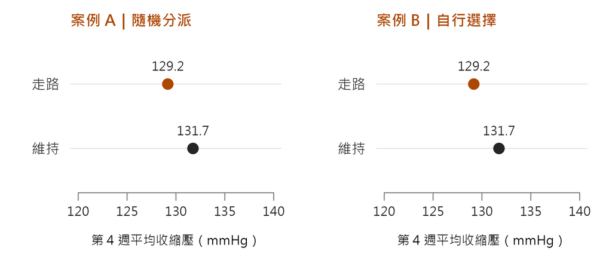

案例 A：隨機分派。案例 B：自行選擇。

第 4 週平均收縮壓：走路 129.2 mmHg；維持 131.7 mmHg。

走路減維持：-2.6 mmHg（由未四捨五入的平均值計算）。

自編虛構資料；差值以未四捨五入的平均值計算。點為組平均，未呈現不確定性，不能單憑圖判定因果。

## 分開描述結果與解釋原因

只描述圖上結果，我可以說：＿＿。

加上分組資訊後，解釋原因還需要：＿＿。

在學習單 A 寫下一項待確認資訊及理由。

先獨立作答，再兩人討論；保留初稿，用另一種顏色修訂。

## Q2／Q3：抽樣、分派與解釋

### Q2｜案例 A 隨機的是？

1. 哪些成人進入門診研究
2. 已招募者接受的組別條件
3. 第 0 與第 4 週的量測順序
4. 兩組各 30 人這個人數

### Q3｜數字相同，表示？

1. 描述差異與因果解釋都相同
2. 可以同樣推廣到所有成人
3. 自選與隨機分派作用相同
4. 描述可相同，因果仍須看設計

兩題分別投票；說明「哪個步驟隨機」以及「數字沒有交代什麼」。

## 招募與分派是兩個步驟

### 目標對象

希望了解哪些成人？

### 進入研究

本例是門診志願者。

### 形成兩組

A 隨機分派；B 自選。

招募影響推廣範圍；分派影響組間比較的因果依據。參考 Penn State STAT 500。

## 自選組別可能混入什麼因素？

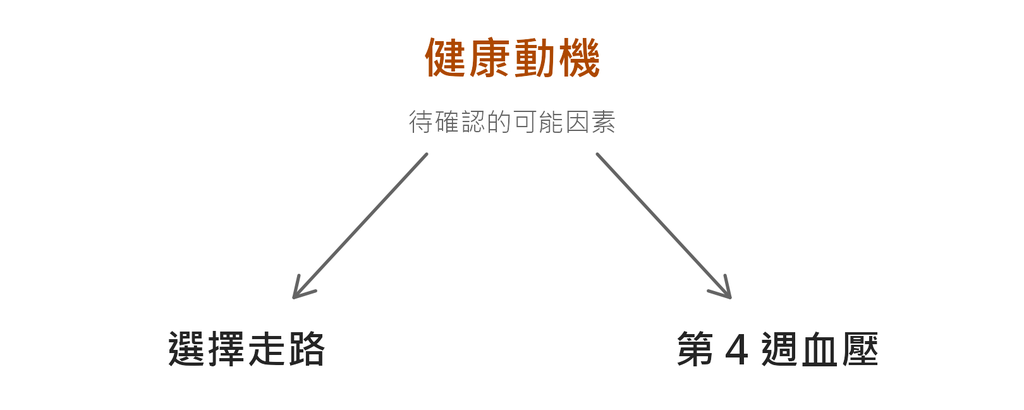

健康動機可能同時影響「選擇走路」與「第 4 週血壓」。

原有運動習慣、健康狀態也可能有類似作用。

待確認：哪些因素影響選組？研究有記錄嗎？

這是待查的替代解釋；題目尚未證實健康動機或其他因素的實際作用。

## 能支持的結論範圍

### 案例 A

分派、追蹤與量測適當時，較能支持「分派到此計畫」的平均因果效果解釋。

不保證單次分組完全平衡。

### 案例 B

目前較適合描述自行選組者的血壓差異。

直接的因果結論仍缺乏排除替代解釋的依據。

兩案都不是從所有成人隨機抽樣，也不能用群體平均差宣稱人人受益。

## 人、訪視與讀值

### 60 人

每人一個 ID

### 120 次訪視

每人第 0、4 週各一次

### 240 次讀值

每次訪視量兩次

本檔儲存每次訪視的平均值；讀值增加，參與者沒有跟著增加。

## 同樣三個人，兩種資料存法

### 寬格式｜一人一列

participant_id、sbp_baseline、sbp_week4

| ID | 第 0 週 | 第 4 週 |
| --- | --- | --- |
| P001 | 129.6 | 122.5 |
| P002 | 145.0 | 134.8 |
| P003 | 144.8 | 145.6 |

血壓單位：mmHg

### 長格式｜一人一次訪視一列

participant_id、week、sbp

| ID | 週次 | 血壓 |
| --- | --- | --- |
| P001 | 0 | 129.6 |
| P001 | 4 | 122.5 |
| P002 | 0 | 145.0 |
| P002 | 4 | 134.8 |
| P003 | 0 | 144.8 |
| P003 | 4 | 145.6 |

表格取自虛構 CSV 的前三人；同一顏色表示同一個 ID。三列變六列，仍是三個人。

## 本週主要比較使用哪些值？

### 第 4 週的組間差

只取每人的第 4 週血壓

60 人，各貢獻一個結果

### 若改問四週內的改變

保留同一人的第 0、4 週

每人先算第 4 週減第 0 週

不同人的獨立性仍需確認，例如同戶或團體介入；有兩次量測不等於主分析一定用全部值。

## Q4：資料包含多少位參與者？

60 人，每人兩次訪視。

每次訪視量兩次，再取平均。

1. 60 人
2. 120 人
3. 240 人
4. 480 人

選完後補一句：不同人是否完全獨立，還要確認什麼？

## 七題計畫：把判斷接成一條路

### 先定義問題與資料

1. 研究問題：對誰、比較什麼？
2. 估計量：方向、時間、單位？
3. 變項：角色與型態？
4. 來源：招募、分派與推論？

### 再規劃分析與結論

5. 結構：哪些值來自同一人？
6. 方法：方向、假設與檢查？
7. 結論：能說什麼、不能說什麼？

不知道的資訊：註明理由與待查項目

七題是檢查彼此是否一致的工具；第一週可先寫白話方法方向。

## 示範：先寫研究問題與估計量

### 第 1 題｜研究問題

在本研究招募的成人中，分派到走路與維持原生活者，第 4 週平均收縮壓差多少？

### 第 2 題｜目標估計量

第 4 週走路組平均收縮壓，減去維持組平均收縮壓。

方向：走路減維持；單位 mmHg。

這裡示範案例 A；負值表示走路組平均較低，並不是每個人的前後下降。

## 寫下第 1–4 題：把理由補齊

以案例 A 完成學習單 B 第 1–4 題。

第 1–2 題沿用示範，確認你能解釋每一項。

第 3 題寫出結果、組別與型態。

第 4 題把「如何招募」與「如何分派」分開。

暫不使用 AI；不用填入剛才圖上的數值，這裡練習的是分析前的規劃。

## 檢查資料時，理由要跟著寫

### 檢查什麼？

ID 是否重複？

血壓單位與數值是否合理？

不同人是否來自同戶或團體？

### 為什麼檢查？

避免把同一人重複計入

避免編碼或輸入錯誤影響比較

判斷可否暫視不同人為獨立

先確認紀錄意義再處理；不能看到重複 ID 就直接刪除，也不能把缺失值改成 0。

## 完成計畫，再依標準互相檢閱

### 完成第 5–7 題

方法：比較第 4 週兩組平均數

檢查：至少兩項，各寫理由

結論：預計報告內容與限制

交換計畫，找出不一致再修訂

### 合格標準

問題具體，時間與比較一致

招募與分派分開說明

觀察單位正確

檢查有理由

結論不越界，修訂有依據

尚未分析就寫「預計報告……」；第一週不要求檢定名稱或公式。

## 參考計畫｜問題、變項與設計

### 第 1–2 題

本研究成人，第 4 週組間平均血壓差。

走路減維持，單位 mmHg。

### 第 3–4 題

結果：第 4 週血壓，連續量。

組別：走路／維持，類別。

門診自願招募，招募後隨機分派。

互評後再對照；補寫不同之處與理由。目標是分派到計畫的平均效果，外推仍需評估。

## 參考計畫｜結構、檢查與結論

### 第 5–6 題

主比較每人一個第 4 週結果。

暫以不同人獨立，確認有無群聚。

比較兩組平均數；查 ID、單位、異常值與相依性。

### 第 7 題

預計報告平均差及不確定性。

依分派、追蹤與量測條件解釋。

不宣稱所有成人或每個人都受益。

改成案例 B：比較意義、可能混淆與結論界線都須跟著改；保留你的修訂理由。

## 查核三句不可靠的回答

「120 個訪視數值，就是 120 個獨立樣本。」

「自選走路組血壓較低，證明走路造成下降。」

「走路組平均較低，所以每個人都會受益。」

教師自編錯誤回覆，非模型實測。逐句寫「查什麼、怎麼改」；常態與 p 值留到後續課程。

## 一筆可檢核的修訂紀錄

原句：有 120 個獨立樣本。

查核：檢視 ID 與時間，60 人各有兩次訪視。

修訂：共有 60 位參與者；同人前後值相依。

理由：增加訪視紀錄，沒有增加參與者。

若使用 AI，另記工具、日期與用途；不能只把語句改流暢，卻沒查資料。

## 換一個情境再判斷

從某校學生名冊隨機抽出 100 人，全數參與。

記錄自行決定的每日含糖飲料量與同日空腹血糖。

研究者沒有指定任何人喝多少。

這是隨機抽樣、隨機分派，還是兩者都有？

自編虛構情境。寫一個關聯問題，再指出一個不能直接下的因果結論。

## Q5：哪個方向回答本週主要問題？

目標：第 4 週走路組減維持組的平均血壓差。

1. 比較兩組第 4 週平均值
2. 只看走路組前後平均改變
3. 合併兩組，計算全體的平均改變

選完後說明另外兩項各回答什麼問題；先確認比較對象與時間，再選方法。

## Q6：哪一筆 AI 查核紀錄最完整？

AI 說：「120 個訪視數值就是 120 位參與者。」

1. 記下工具名稱，直接採用原句
2. 查 ID 與時間，改成 60 人並記錄理由
3. 改寫成「樣本很多」，沒有檢查資料

選完後指出查核的證據。這是課堂自編情境，小測不使用 AI。

## 把七題計畫用在另一個問題

作業題稿：睡眠時數與反應時間的關聯。

約 600–900 字，寫出七題判斷及待確認資訊。

附初稿、修訂理由；有用 AI 才記錄使用與查核。

先回答：誰是一個觀察單位？能下什麼結論？

本題不要求 R；是否採用、繳交格式與期限，以 ee-class 正式作業頁面為準。

## 交出計畫，準備下一週

交回計畫卡，保留初稿與修訂理由。

確認可登入 ee-class、找到教材與作業公告。

第 2 週前註冊 posit.cloud。

9/17 到計算機中心 I002，開始 R 實習 1。

下次從你的計畫出發，繼續確認資料來源與相依結構，再匯入資料。